# Microbial Informatics

## Lecture 14

Patrick D. Schloss, PhD (microbialinformatics.github.io)  
Department of Microbiology & Immunology

## Announcements

- Homework 3 is due today
- Have posted some guide lines to follow for Project 1
- No class on Tuesday (Fall break); Next Friday, the first hour of class will be a lecture
- Start programming discussion next Thursday!
- Read *The Art of R Programming* (Chapter 1: Getting Started)

## Review

- Type I and Type II errors
- ANOVA is a generalized form of the t-test (Parametric)
- Kruskall-Wallis is a generalized form of the Wilcox-test (Non-parametric)

## Learning objectives

- Regression
- Correlation

## Motivation

- You have isolated an enzyme from a novel bacterium that you are convinced will solve the world's energy problems. But first you need to characterize its kinetics on a variety of substrates.
- For a variety of substrate concentrations, you run a colormetric assay and quantify the activity (amount of product formed per unit time) for each substrate concentration. Your data look like so...

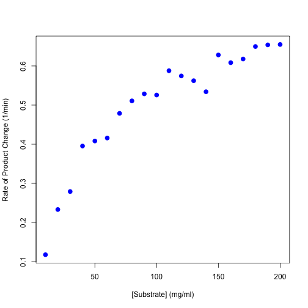

## Motivation

- You recall from your undergraduate biochemistry class doing a lab on Michaelis-Menton kinetics and that there is a model that looks like this:

\[\frac{dP}{dt}=V_o=\frac{V_{max}[S]}{K_m+[S]}\]

- How do you figure out \(V_{max}\) and \(K_m\)?

## Motivation

We can make a Lineweaver-Burk plot

\[\frac{1}{V_o} = \frac{K_m + [S]}{V_{max}[S]}\]

or...

\[\frac{1}{V_o} = \frac{K_m}{V_{max}}(\frac{1}{[S]}) + \frac{1}{V_{max}}\]

## How do we fit this plot?

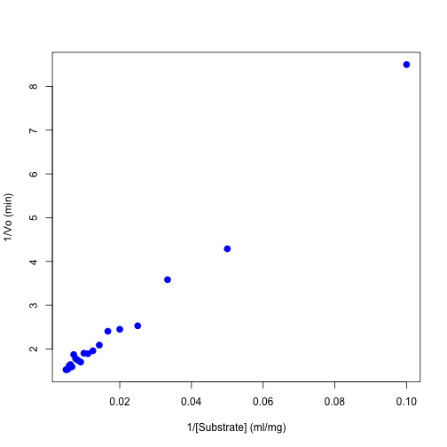

## How do we fit this plot?

\[\frac{1}{V_o} = \frac{K_m}{V_{max}}(\frac{1}{[S]}) + \frac{1}{V_{max}}\]

- If we can fit a line through the data we can get our Vmax from the intercept and our Km from the slope
- Cue... linear regression!

## Linear regression

\[y_i = \alpha + \beta x_i + \epsilon_{ij}\]

- We need to fit this model to estimate the values of \(\alpha\) and \(\beta\)
- We'll come back to talking about \(\epsilon\) later

## What we really want to do...

- Minimize the distances between the line we fit through the data and the observed values.
- This distance is the residual - minimize the squared residuals...

\[SS_{res} = \sum(y_i - (\alpha + \beta x_i) )^2\]

- Recall how to minimze a function?

## After some calculus and algebra...

\[\hat{\beta} = \frac{\sum(x_i-\bar x)(y_i-\bar y)}{\sum(x_i-\bar x)^2}\] \[\hat{\alpha} = \bar y - \hat{\beta}\bar x\]

## Let's do some calculations...

```r
xbar <- mean(invS)
ybar <- mean(invV)

beta <- sum((invS-xbar)*(invV-ybar))/sum((invS-xbar)^2)
alpha <- ybar - beta * xbar
```

## Our fit

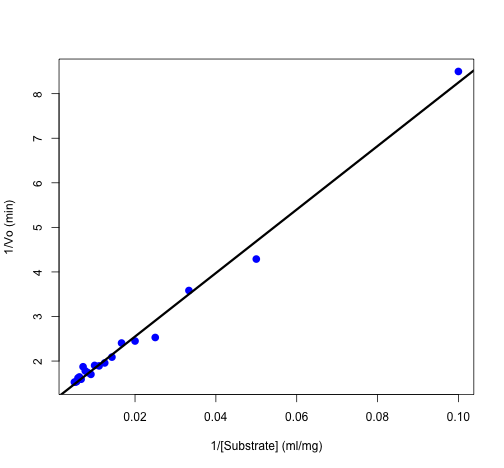

```r
plot(invS, invV, lwd = 3, col = "blue", pch = 19, xlab = "1/[Substrate] (ml/mg)",
    ylab = "1/Vo (min)")
abline(b = beta, a = alpha, lwd = 3)
```

## Returning to biology

\[\frac{1}{V_o} = \frac{K_m}{V_{max}}(\frac{1}{[S]}) + \frac{1}{V_{max}}\]

\[\hat{\alpha} = \frac{1}{V_{max}} = 1.1252\] \[\hat{\beta} = \frac{K_m}{V_{max}} = 71.2447\]

So we get a Vmax of 0.89 and a Km of 63.32

## How to do this with built in R function?

```r
lm(invV~invS)
```

```
##
## Call:
## lm(formula = invV ~ invS)
##
## Coefficients:
## (Intercept)         invS
##        1.13        71.24
```

## What is the null hypothesis we're trying to test?

\[\hat{\beta} = 0\]

- How to test?

\[t=\frac{\hat{\beta}}{SE(\hat{\beta})}\]

with n-2 degrees of freedom

## How to do this with built in R function?

```r
summary(lm(invV~invS))
```

## How to do this with built in R function?

```
##
## Call:
## lm(formula = invV ~ invS)
##
## Residuals:
##     Min      1Q  Median      3Q     Max
## -0.3986 -0.0555  0.0255  0.0765  0.2485
##
## Coefficients:
##             Estimate Std. Error t value Pr(>|t|)
## (Intercept)   1.1252     0.0477    23.6  5.5e-15 ***
## invS         71.2447     1.6892    42.2  < 2e-16 ***
## ---
## Signif. codes:  0 '***' 0.001 '**' 0.01 '*' 0.05 '.' 0.1 ' ' 1
##
## Residual standard error: 0.165 on 18 degrees of freedom
## Multiple R-squared:  0.99,   Adjusted R-squared:  0.989
## F-statistic: 1.78e+03 on 1 and 18 DF,  p-value: <2e-16
```

## Our fit

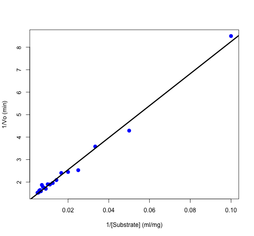

What do you notice about the fit?

## How "good" is our fit?

- The R squared value!
- Represents the percentage of the variance in the data that is reduced by going from a one parameter model (\(\alpha\)) to the linear, two parameter model

## A better fit (Chapter 16)...

```r
mm <- function(S, vmax, Km){
    Vo <- vmax * S / (Km + S)
    return(Vo)
}

nonlinear.fit <- nls(dPdt ~ mm(S, v, k), start=c(v=1, k=60))
```

## A better fit (Chapter 16)...

```r
summary(nonlinear.fit)
```

[output not shown]

## A better fit (Chapter 16)...

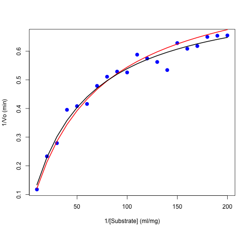

```r
plot(S, dPdt, lwd = 3, col = "blue", pch = 19, xlab = "1/[Substrate] (ml/mg)",
    ylab = "1/Vo (min)")
lines(S, mm(S, vmax = lin.vmax, Km = lin.Km), col = "red", lwd = 2)
points(S, predict(nonlinear.fit), type = "l", lwd = 2)
```

## Correlation

[figure not shown]

## Correlation

[figure not shown]

Wikipedia

## Parametric: Pearson correlation

- Parametric
- Linear relationship

\[r=\frac{(x_i-\bar x)(y_i-\bar y)}{\sqrt{\sum(x_i-\bar x)^2\sum(y_i-\bar y)^2}}\]

```r
Sbar <- mean(S)
dPdtbar <- mean(dPdt)
r <- sum((S-Sbar)*(dPdt-dPdtbar))/sqrt(sum((S-Sbar)^2)*sum((dPdt-dPdtbar)^2))
r
```

```
## [1] 0.915
```

## Parametric: Pearson correlation

```r
cor(S, dPdt, method="pearson")
```

```
## [1] 0.915
```

```r
cor.test(S, dPdt, method="pearson")
```

```
##
##  Pearson's product-moment correlation
##
## data:  S and dPdt
## t = 9.62, df = 18, p-value = 1.615e-08
## alternative hypothesis: true correlation is not equal to 0
## 95 percent confidence interval:
##  0.7939 0.9663
## sample estimates:
##   cor
## 0.915
```

## Non-parametric: Spearman correlation

```r
cor(S, dPdt, method="spearman")
```

```
## [1] 0.9789
```

```r
cor.test(S, dPdt, method="spearman")
```

```
##
##  Spearman's rank correlation rho
##
## data:  S and dPdt
## S = 28, p-value = 6.521e-06
## alternative hypothesis: true rho is not equal to 0
## sample estimates:
##    rho
## 0.9789
```